# Machine Learning I: **Classification (Overview)**

This notebook provides a brief overview of classification, which is a type of [supervised](https://en.wikipedia.org/wiki/Supervised_learning) learning. In the context of classification, "supervised" means that the classes are known.

For example, imagine that we have previously categorized 100 bottles of wine into "Good" and "Bad" catgories, and that each bottle of wine can be characterized by a variety of factors including color, price, and age. The **labels** or **target values** are "Good" and "Bad", and the **features** are color, price, age, etc. The supervised learning problem can be roughly stated as follows:

- Use the features (color, price, age, etc.) to learn the differences between "Good" and "Bad" bottles of wine
- Apply this learning to a set of new set of wine bottles, to predict whether you would categorize each as "Good" or "Bad"

More generally, the goals of classification are:

- To build a statistical model of the mapping between features and labels in a [training set](https://en.wikipedia.org/wiki/Training,_validation,_and_test_sets).
- To use that model to assign labels to novel cases in a [test set](https://en.wikipedia.org/wiki/Training,_validation,_and_test_sets).
- To conduct validation: repeat training and testing on a wide variety of training and test sets to test the validity of the classification approach.

In other words, a classifier's inputs are **features** and its outputs are **labels**.

**Mini Glossary**:

| Term | Definition |
| --- | --- |
| *label* or *target value* | an integer or text label describing the group or category to which a specific observation belongs |
| *feature* | a characteristic of an observation |
| *model* | a mathematical and/or statistical representation of the relation between observations and labels |
| *observation* | a real-world object, represented using a a set of features, and usually saved as one row in a data table (e.g. CSV file) |
| *training set* | the observations and their labels used to train a classifier |
| *test set* | novel observations, (possibly) with unknown labels |

## A simple classifier

One of the simplest types of classifiers is a [K-Nearest Neighbors](https://en.wikipedia.org/wiki/K-nearest_neighbors_algorithm) (KNN) classifer. The "K" in "K-Nearest Neighbors" is an integer that represents the number of *observations* to which another observation will be compared. K can range from 1 to the maximum number of observations for a given class.

Let's try a simple example. First let's import the packages we'll need:

```python
import numpy as np
from matplotlib import pyplot as plt
from sklearn.neighbors import KNeighborsClassifier
```

Next let's define simple *features* (x) and *labels*:

```python
# features:
# array shape:  (number of observations , number of features)
x = np.array([
    [1, 0],
    [2, 4],
    [3, 2],
    [12, 0],
    [13, 2],
    [14, 1],
    [7, 8],
    [10, 7],
    [8, 9],
])

# labels (must be one for each observation)
labels = np.array([0, 0, 0,    1, 1, 1,    2, 2, 2])
```

Let's next visualize the data so that we can see more clearly perceive the relationship between the *features* and *labels*.

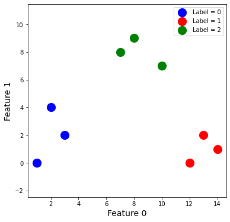

```python
x0     = x[labels==0]  # features for all observations in Group "0"
x1     = x[labels==1]  # features for all observations in Group "1"
x2     = x[labels==2]  # features for all observations in Group "2"


plt.figure(figsize=(6,6))
ax     = plt.axes()
colors = ['b','r','g']
ax.scatter( x0[:,0], x0[:,1], color=colors[0], s=200, label='Label = 0' )
ax.scatter( x1[:,0], x1[:,1], color=colors[1], s=200, label='Label = 1' )
ax.scatter( x2[:,0], x2[:,1], color=colors[2], s=200, label='Label = 2' )
ax.set_xlabel('Feature 0', size=14)
ax.set_ylabel('Feature 1', size=14)
ax.axis('equal')
ax.legend()
plt.show()
```

We can see that these data form three distinct clusters.

We can next train a KNN classifier as follows:

```python
knc = KNeighborsClassifier(n_neighbors=2)
knc.fit(x, labels)

print( knc )
```

```
KNeighborsClassifier(n_neighbors=2)
```

Now that we have trained the classifier, we can check what *label* it will predict for a new *observation*.

For example, imagine that we have a new observation: x_new = [8, 10] (note that this observation is not in our original list of features "x"). Looking at the figure above, we know that this new observation is most similar to the observations in Group "2". Let's check whether our trained classifier also predicts this label for the new observation:

```python
x_new = [8, 10]
label_new = knc.predict( [ x_new ] )

print( label_new )
```

```
[2]
```

Excellent! Our classifier has correctly predicted the *label* for our new observation.

We can check multiple new observations by creating a list of new observations like this:

```python
x_new = [ [8, 10], [2,2], [12,2] ]
label_new = knc.predict( x_new )

print( label_new )
```

```
[2 0 1]
```

Great! We have just completed training and testing. The remainder of this chapter considers the main ways in which classification problems (both training and testing) can become more complex.

For simplicity, this chapter considers only the case of **two features**, like in this notebook. Using only two features is convenient because the data can be easily visualized.

In general, classification and other machine learning problems involve many more than two features. Nevertheless, the procedures and the basic analysis code does not change very much.

The final chapter ("Dimensionality Reduction") considers the case of many features in more detail.